# Artificial Intelligence Agent Chatbot for Small and Medium Enterprise Business Performance: Impact on operational decision-making in retail SMEs

## Introduction

This research project focuses on designing, implementing, and empirically evaluating a production-grade Artificial Intelligence (AI) Agent Chatbot deployed via Telegram, specifically tailored for Small and Medium Enterprise (SME) owners within the retail sector. By leveraging a cutting-edge architecture consisting of the Gemini Large Language Model (LLM), LangChain orchestration framework, Retrieval-Augmented Generation (RAG), and a secure MySQL relational database backend, this analysis aims to prove the efficiency of AI agent chatbot can provide to SMEs in improving their data-driven decision-making process.

## Workflow

To empirically validate the operational efficacy of the proposed solution, the analysis is conducted through 4 main stages as follows:

1. **Data Profiling:** A rigorous data quality assessment phase that inspects data schemas, validates variable typings, and scans for structural integrity or missing entries, ensuring the dataset is completely clean before running statistical models.
2. **Exploratory Data Analysis (EDA):** The application of graphical visualization techniques (`matplotlib` and `seaborn`) to assess the overall information of the experiment, result distribution, and variance of Task Completion Time ("TCT") across three experimental groups: Microsoft Excel, a hybrid SQL + Excel workflow, and the proposed AI Agent Chatbot.
3. **Friedman Test:** A robust, non-parametric repeated-measures omnibus test executed to determine whether there are statistically significant differences in TCT across all three analytical methods simultaneously, effectively controlling for Type I error inflation.
4. **Wilcoxon Signed-Rank Test:** A post-hoc pairwise comparison framework with an integrated Bonferroni adjustment is employed to compare the experimental pairs and mathematically confirm the performance and efficiency superiority of the AI Agent system.

## 1. Data Profiling

```python
import pandas as pd
import numpy as np
import matplotlib.pyplot as plt
import seaborn as sns
from scipy import stats
import pymysql

#Import the library to connect to MySQL database
from sqlalchemy import create_engine

#Import class for chart visualization
from service.chart_package import ChartDrawer
```

```python
# !pip install --upgrade matplotlib ipykernel
```

```python
# Configure the MySQL connection
db_user = "root"
db_password = "root"
db_host = "localhost"
db_port = 3306
db_name = "capstone_db"

#Create the engine to connect to MySQL database using SQLAlchemy
engine = create_engine(f"mysql+pymysql://{db_user}:{db_password}@{db_host}/{db_name}")

# Query the data from the database

# TCT result
query_result = "SELECT * FROM tct_result"
tct_result = pd.read_sql(query_result, con=engine)

# TCT question
query_question = "SELECT * FROM tct_question"
tct_question = pd.read_sql(query_question, con=engine)

# TCT result dataframe
tct_df = pd.merge(tct_result, tct_question, left_on="taskid", right_on="taskid", how="left")

print(tct_df.head())
```

```
   resultid userid skill_level  taskid  time_excel  time_sql_excel  time_ai  \
0         1     U1        High       1         202             165       85
1         2     U1        High       2         428             198      109
2         3     U1        High       3         242             202      137
3         4     U1        High       4         272             224       84
4         5     U1        High       5         240             206       68

  difficulty                                            content
0       Easy  What was our daily revenue from May 1st to May...
1       Easy  How many total orders were placed from May 1st...
2       Easy  What is the total discount amount from May 1st...
3       Easy  How many unique customers made a purchase this...
4       Easy  What is the total profit generated from Standa...
```

```python
# Check the profile of the dataset
tct_df.info()
```

```
<class 'pandas.core.frame.DataFrame'>
RangeIndex: 100 entries, 0 to 99
Data columns (total 9 columns):
 #   Column          Non-Null Count  Dtype
---  ------          --------------  -----
 0   resultid        100 non-null    int64
 1   userid          100 non-null    object
 2   skill_level     100 non-null    object
 3   taskid          100 non-null    int64
 4   time_excel      100 non-null    int64
 5   time_sql_excel  100 non-null    int64
 6   time_ai         100 non-null    int64
 7   difficulty      100 non-null    object
 8   content         100 non-null    object
dtypes: int64(5), object(4)
memory usage: 7.2+ KB
```

```python
# check the description of numerical fields in the dataset
tct_df.describe()
```

|  | resultid | taskid | time_excel | time_sql_excel | time_ai |
| --- | --- | --- | --- | --- | --- |
| count | 100.000000 | 100.000000 | 100.000000 | 100.000000 | 100.000000 |
| mean | 50.500000 | 10.500000 | 379.650000 | 422.380000 | 115.010000 |
| std | 29.011492 | 5.795331 | 154.870254 | 255.053363 | 51.102688 |
| min | 1.000000 | 1.000000 | 108.000000 | 96.000000 | 31.000000 |
| 25% | 25.750000 | 5.750000 | 270.000000 | 224.750000 | 75.500000 |
| 50% | 50.500000 | 10.500000 | 342.500000 | 362.000000 | 106.000000 |
| 75% | 75.250000 | 15.250000 | 458.500000 | 499.500000 | 154.250000 |
| max | 100.000000 | 20.000000 | 1104.000000 | 1218.000000 | 264.000000 |

```python
# Check the shape of the dataset
tct_df.shape
```

```
(100, 9)
```

### Conclusion

- No major data issues are found.
- Zero null values across all critical fields.
- The flawless dataset confirms that the experiment result was accurately collected, eliminating potential bias and laying strong foundation for downstream mathematical hypothesis testing.

# 2. Exploratory Data Analysis

```python
# Initiate the chart_package
drawer = ChartDrawer(
    style='darkgrid',
    palette='husl'
)
```

```python
#Check the correlation between experiment results

print(tct_df[['time_excel','time_sql_excel','time_ai']].corr(numeric_only=True))
```

```
                time_excel  time_sql_excel   time_ai
time_excel        1.000000        0.871852  0.527547
time_sql_excel    0.871852        1.000000  0.379163
time_ai           0.527547        0.379163  1.000000
```

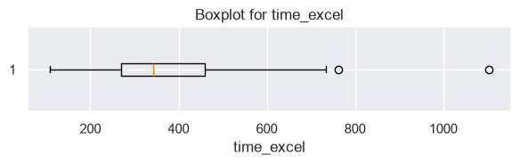

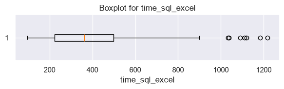

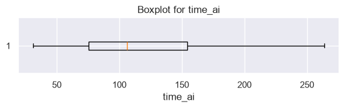

```python
# Check the spreading of experiment
cols = ['time_excel','time_sql_excel','time_ai']

for col in cols:
    plt.figure(figsize=(6,2))
    plt.boxplot(tct_df[col], orientation = "horizontal")
    plt.title(f"Boxplot for {col}")
    plt.xlabel(col)
    plt.tight_layout()
    plt.show()
```

```python
# Pre-define the dataframe
df = tct_df.melt(
    id_vars=['userid', 'taskid', 'difficulty','skill_level'],
    value_vars=cols,
    var_name="tool",
    value_name="time_seconds"
)

# Replace the name of tool
df['tool'] = df['tool'].replace(
    {
        'time_excel': "Excel",
        'time_sql_excel': "SQL + Excel",
        'time_ai': "AI agent",
    }
)

# Order the difficulty
df['difficulty'] = pd.Categorical(df['difficulty'], categories=['Easy', 'Medium', 'Hard'], ordered=True)

# Change the data type of taskid
df['taskid'] = df['taskid'].astype("string")

# Check the df
df
```

|  | userid | taskid | difficulty | skill_level | tool | time_seconds |
| --- | --- | --- | --- | --- | --- | --- |
| 0 | U1 | 1 | Easy | High | Excel | 202 |
| 1 | U1 | 2 | Easy | High | Excel | 428 |
| 2 | U1 | 3 | Easy | High | Excel | 242 |
| 3 | U1 | 4 | Easy | High | Excel | 272 |
| 4 | U1 | 5 | Easy | High | Excel | 240 |
| ... | ... | ... | ... | ... | ... | ... |
| 295 | U5 | 16 | Medium | Low | AI agent | 185 |
| 296 | U5 | 17 | Medium | Low | AI agent | 140 |
| 297 | U5 | 18 | Medium | Low | AI agent | 216 |
| 298 | U5 | 19 | Hard | Low | AI agent | 223 |
| 299 | U5 | 20 | Hard | Low | AI agent | 151 |

300 rows × 6 columns

```python
#Variables
tools = ["Excel", "SQL + Excel", "AI agent"]
s_levels = ['High', 'Low']
```

```
Total question:
20
```

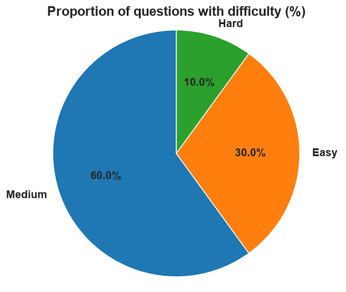

```python
# The questions for experiment
q_stat = tct_question['difficulty'].value_counts().reset_index()
q_stat.columns = ["difficulty",'count']

# Total question
print("Total question:")
print(q_stat['count'].sum())

# Proportion of question by difficulty level
drawer.pie_chart(
    data=list(q_stat['count']),
    labels=list(q_stat['difficulty']),
    autopct='%1.1f%%',
    title="Proportion of questions with difficulty (%)",
    figsize=(6,5)
)
```

```
Total number of participant:
5
```

[figure not shown]

```python
# The participant
u_stats = tct_result[['userid','skill_level']].drop_duplicates()
skill_stats = u_stats['skill_level'].value_counts().reset_index()
skill_stats.columns = ["skill_level", 'count']

# total number of participant
print("Total number of participant:")
print(len(u_stats))

# proportion of participant by skill level
drawer.pie_chart(
    data=list(skill_stats['count']),
    labels=list(skill_stats['skill_level']),
    autopct='%1.1f%%',
    title="Proportion of questions with difficulty (%)",
    figsize=(6,5)
)
```

Two pie charts visualize the structural proportions of task difficulty and participant skill levels within the experimental sample pool. According to the charts:

- The task difficulty chart illustrate the distribution of complexity of the questions where 60% is Medium, 30% is Easy, and 10% is Hard tasks. This reflects the real-world operational reality of a retail SME, where the majority of queries consist of routine operational checks with medium and easy tasks like pulling daily sales or checking low inventory, with some occasional complex diagnostic tasks.
- The skill level chart indicates a balanced sample consisting of 60% high-skill and 40% low-skill users. By diversifying the participants' skill levels in data analytics, this experiment aims to evaluate the impact and efficiency variance across different participant groups while employing various methods.

[output not shown]

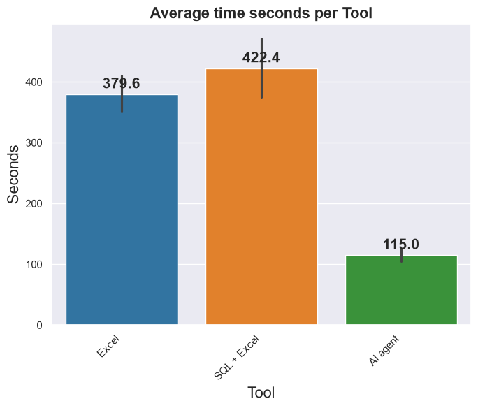

```python
# The average time by tool
drawer.bar_chart(
    data=df,
    x='tool',
    y='time_seconds',
    title='Average time seconds per Tool',
    xlabel="Tool",
    ylabel='Seconds',
    figsize = (7,6)
)
```

[output not shown]

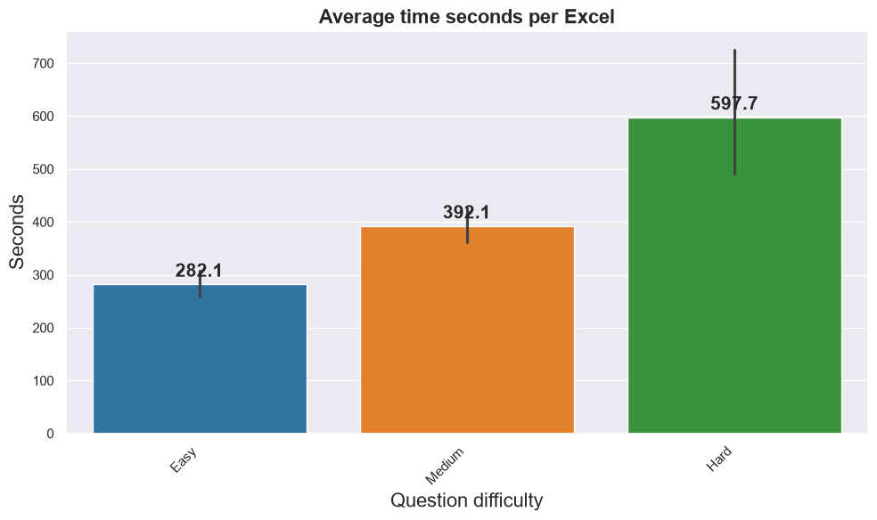

[output not shown]

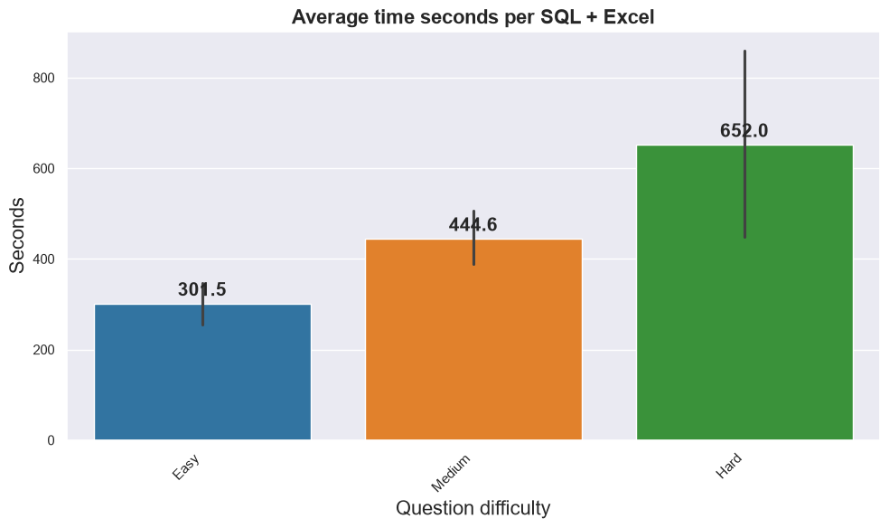

[output not shown]

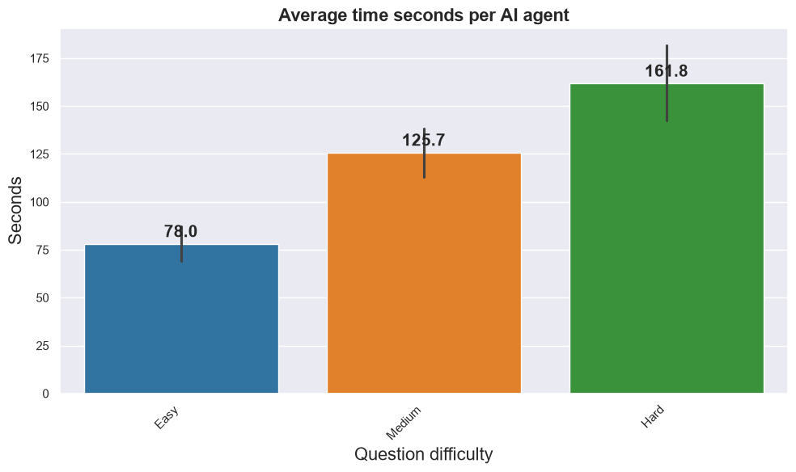

```python
# The average time by difficulty
for tool in tools:
    drawer.bar_chart(
        data=df[df['tool'] == tool],
        x='difficulty',
        y='time_seconds',
        title= f'Average time seconds per {tool}',
        xlabel="Question difficulty",
        ylabel='Seconds',
        figsize = (10,6)
    )
```

A group of bar charts demonstrate the difference of TCT across analytical tools by task difficulty levels (e.g., Easy, Medium, Hard).

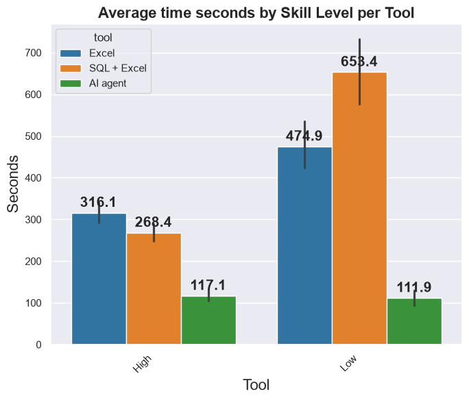

```python
# The average time by tool
drawer.bar_chart(
    data=df,
    x='skill_level',
    y='time_seconds',
    hue='tool',
    title='Average time seconds by Skill Level per Tool',
    xlabel="Tool",
    ylabel='Seconds',
    figsize = (7,6)
)
```

A group of bar charts evaluating how user technical skill levels influence the TCT across different tools.

In the **Excel** and **SQL + Excel** groups, there is a severe performance difference between low-skill users and high-skill users:

- In overall, low-skill participants take longer than high-skill participants.
- For highly skilled users, using SQL to extract data and then visualizing it in Excel proves more effective than only using Excel for the same task. Meanwhile, the opposite is true for the group of participants with fewer skills, as SQL becomes a major challenge when they perform the task.

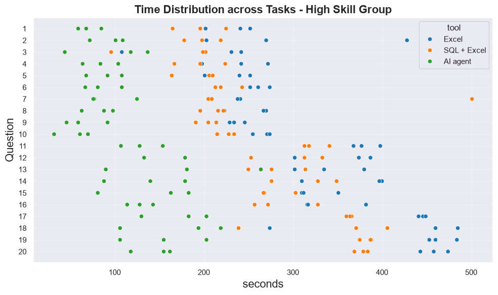

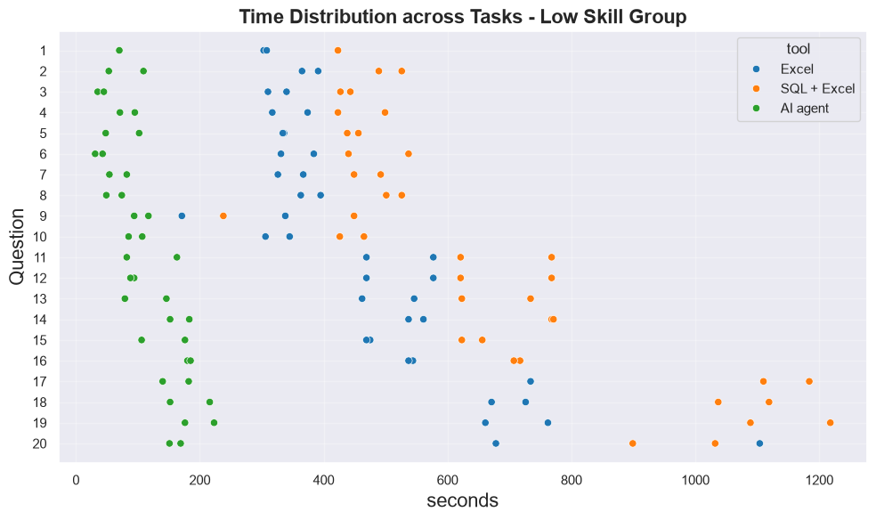

```python
# The distribution of time by skill, distinguished by question difficulty
df_high = df[df['skill_level'] == "High"]
df_low = df[df['skill_level'] == "Low"]

# Participant with high skill
for s_level in s_levels:
    drawer.scatter_plot(
        data=df[df['skill_level'] == s_level],
        x='time_seconds',
        y='taskid',
        hue='tool',
        title=f'Time Distribution across Tasks - {s_level} Skill Group',
        xlabel="seconds",
        ylabel="Question"
    )
```

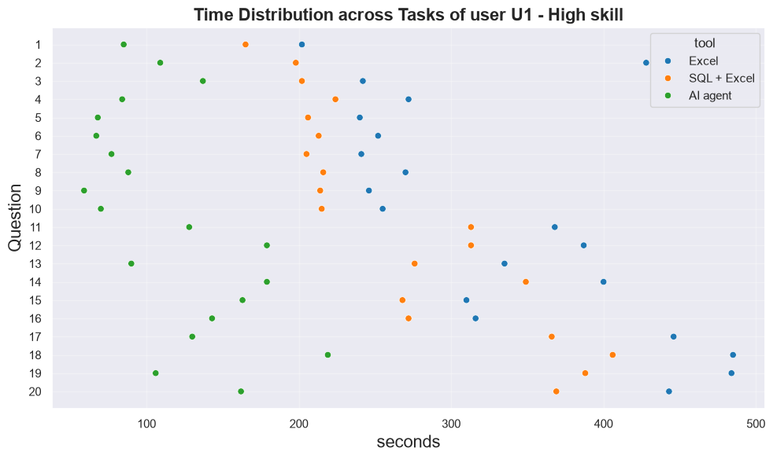

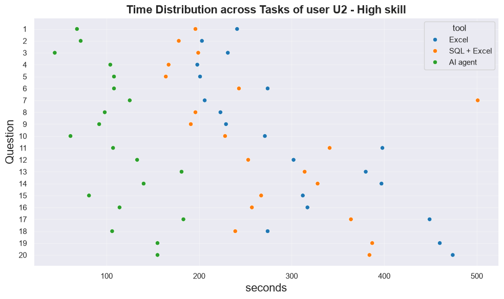

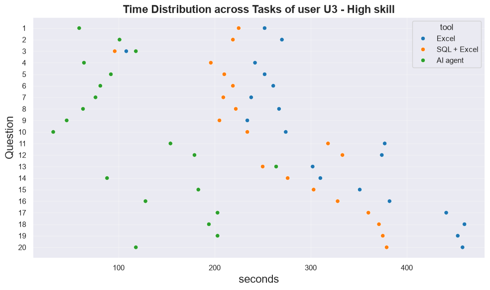

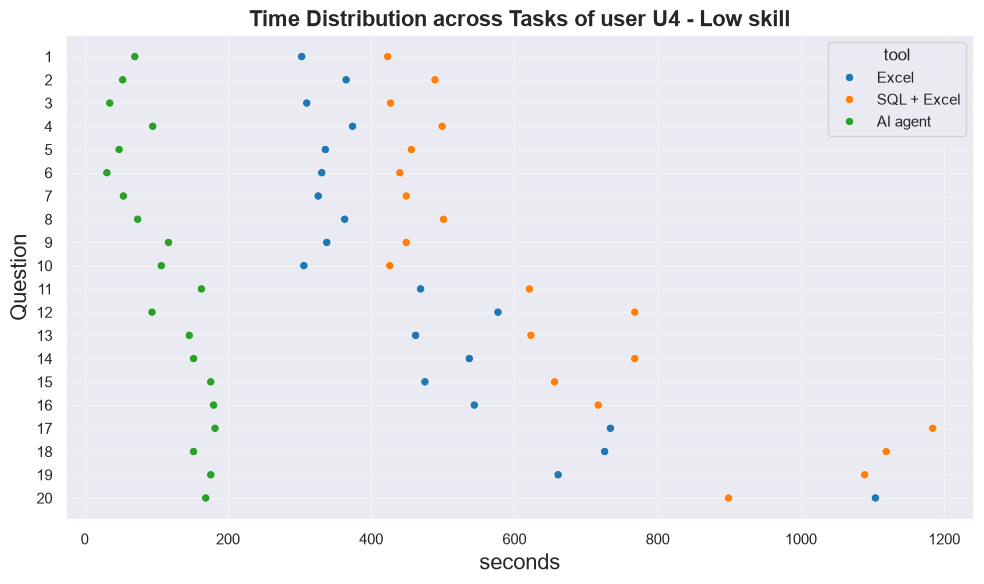

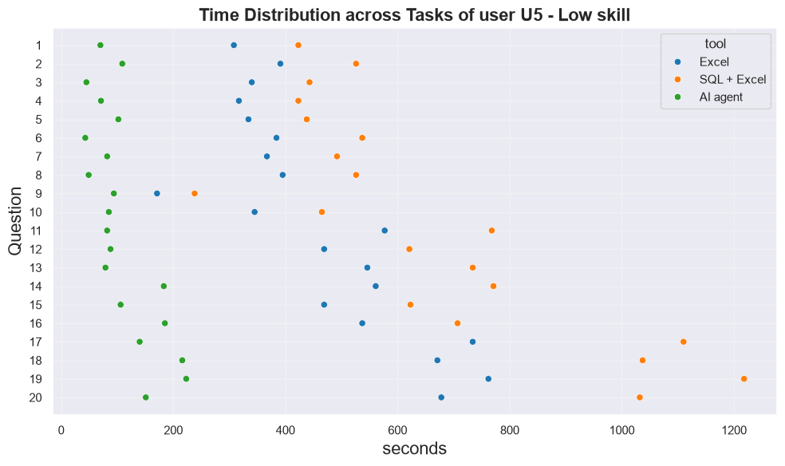

```python
# Individual user result
users = df['userid'].unique()

# Draw each individual
for user in users:
    s_level = df[df['userid'] == user]['skill_level'].unique()[0]
    drawer.scatter_plot(
        data=df[df['userid'] == user],
        x='time_seconds',
        y='taskid',
        hue='tool',
        title=f'Time Distribution across Tasks of user {user} - {s_level} skill',
        xlabel="seconds",
        ylabel="Question"
    )
```

The implementation of `.scatter_plot()` to map individual data points across two dimensions. The first set of scatter plots categorizes the data by `skill_level` (e.g., high-skill vs low-skill groups), while the second set loops through unique `userid` to illustrate isolated performance charts for each individual participant. In these plots, the Y-axis represents the specific question, the X-axis show the time in seconds, and the hue differentiates the three analytical tools.

# 3. Task Completion Time experiment testing

# Statistical Hypotheses

- **Null Hypothesis ($H_0$):** There is no significant difference in the distribution of Task Completion Times across the three analytical tools. The probability of any tool achieving a faster completion time is equal, indicating no significant difference in overall operational efficiency.
- **Alternative Hypothesis ($H_1$):** There is a significant difference in the distribution of Task Completion Times across the three analytical tools. At least one tool dominates the others, consistently demonstrating faster completion times and higher operational efficiency across subjects.

## A. Friedman Omnibus test

The **Friedman test** is a non-parametric statistical test developed by Milton Friedman. This method is used to detect differences in treatments across multiple test attempts when the same subject are used for each treatment.

### How the Friedman test works

Instead of looking at the raw seconds, the Friedman test converts the raw data into **Ordinal Ranks** within each user's task block. For example, if a user takes 500 seconds using Excel tool, 1200 seconds using SQL and Excel, and 100 seconds using AI agent system for a single task, the result are then ranked as 2, 3, and 1, respectively. Subsequently, the algorithm then sum these ranks across all trials. Using a math formula, the test evaluates how unevenly these ranks are spread out to produce a single test statistic, and compares this number to a standard distribution table to generate a p-value for identifying whether the result is statistical significant between the conditions.

### Justification

The reasons for adopting Friedman test:

1. The experiment is designed under a within-subjects approach evaluating three distinct analytical conditions on a same group of users.
2. The task completion time data in this experiment usually violates the assumption of normal distribution, which would not suitable to Repeated Measures ANOVA approach. Instead, the Friedman test is non-parametric which is highly robust and does not strictly rely on normal distribution requirements.
3. Attempting to run multiple isolated pairwise test significantly increase the risk of false-positive conclusions, which is known as Type I Error. The Friedman test functions as a gatekeeper and evaluates all conditions simultaneously under a single test statistic to control the overall error rate.

```python
# Extract the time for each tool
time_excel = tct_df['time_excel']
time_sql = tct_df['time_sql_excel']
time_ai = tct_df['time_ai']

# Execute Friedman test
chi_square, p_value = stats.friedmanchisquare(time_excel, time_sql, time_ai)

# Print out the result

print("--- FRIEDMAN OMNIBUS TEST RESULTS")
print(f"Chi-square value: {chi_square: .4f}")
print(f"p-value: {p_value: .6e}")

if p_value < 0.05:
    print("Conclusion: Reject the Null Hypothesis (H0). There is a statistically significant different in TCT across the tools. Proceed to Post-Hoc analysis.")
else:
    print("Conclusion: Fail to reject the Null Hypothesis (H0). There is no statistically significantly different in TCT across the tools. Stop analysis.")
```

```
--- FRIEDMAN OMNIBUS TEST RESULTS
Chi-square value:  143.3400
p-value:  7.483667e-32
Conclusion: Reject the Null Hypothesis (H0). There is a statistically significant different in TCT across the tools. Proceed to Post-Hoc analysis.
```

## B. Post-hoc analysis: Wilcoxon Signed-Rank test with Bonferroni correction

Since the Friedman Omnibus test only confirms that an overall difference exists, a Post-Hoc Analysis is strictly required to identify exactly which pairwise comparisons are significant. Accordingly, the *Wilcoxon Signed-Rank test* is utilized to test each pair with the *Bonferroni Correction* to maintain the statistical rigor.

### Operational mechanics

1. *Wilcoxon Signed-rank test:* the test calculates the differences between each pair, ranks the absolute values of these differences, and then compares the sum of the positive ranks to the sum of the negative ranks. If the AI Agent tool consistently reduces the time compared to Excel or SQL, the negative differences will dominate.
2. *Bonferroni Correction:* When running 3 consecutive pairwise tests, the probability of making a Type I error inflates from 5% to approximately 14.2%. Consequently, Bonferroni requires to divide the target $\alpha$ by 3 (New $\alpha = 0.0167$). Therefore, to be declared "statistically significant", the p-value must now fall below $0.0167$.

### Justification

To prove the business value of the AI agent system, the performance of the system must be demonstrated that it is superior to both the traditional Excel tool and the advanced method combining SQL and Excel tools. Accordingly, the Wilcoxon test is the most suitable method to handle pairwise test for a within-subjects experiment, while the Bonferroni correction acts as a statistical safeguard, ensuring that the final result are highly reliable and statistically significant.

### Statistical Hypotheses for each pair in Wilcoxon Signed-rank test

- **Null Hypothesis ($H_0$):** The median difference in TCT between Tool A and Tool B is zero.
- **Alternative Hypothesis ($H_1$):** The median difference in TCT between Tool A and Tool B is not zero.

```python
# Set Bonferroni alpha level
alpha = 0.05
comparison = 3

bon_alpha = alpha/comparison

print(f"Original alpha level: {alpha: .4f}")
print(f"Adjusted Bonferroni alpha level: {bon_alpha: .4f}")
```

```
Original alpha level:  0.0500
Adjusted Bonferroni alpha level:  0.0167
```

```python
#1. Comparison 1: Excel vs AI Agent
stat_1, p_1 = stats.wilcoxon(time_excel, time_ai)
sig_1 = "SIGNIFICANT" if p_1 < bon_alpha else "NOT SIGNIFICANT"
print(f"[Pair 1] Excel vs. AI Agent     : W-Stat = {stat_1:<6.1f} | p-value = {p_1:.2e} -> {sig_1}")
```

```
[Pair 1] Excel vs. AI Agent     : W-Stat = 1.0    | p-value = 4.01e-18 -> SIGNIFICANT
```

```python
# 2. Comparison 2: SQL+Excel vs AI Agent
stat_2, p_2 = stats.wilcoxon(time_sql, time_ai)
sig_2 = "SIGNIFICANT" if p_2 < bon_alpha else "NOT SIGNIFICANT"
print(f"[Pair 2] SQL+Excel vs. AI Agent : W-Stat = {stat_2:<6.1f} | p-value = {p_2:.2e} -> {sig_2}")
```

```
[Pair 2] SQL+Excel vs. AI Agent : W-Stat = 3.0    | p-value = 4.26e-18 -> SIGNIFICANT
```

```python
# 3. Comparison 3: Excel vs SQL+Excel
stat_3, p_3 = stats.wilcoxon(time_excel, time_sql)
sig_3 = "SIGNIFICANT" if p_3 < bon_alpha else "NOT SIGNIFICANT"
print(f"[Pair 3] Excel vs. SQL+Excel    : W-Stat = {stat_3:<6.1f} | p-value = {p_3:.4f} -> {sig_3}")
```

```
[Pair 3] Excel vs. SQL+Excel    : W-Stat = 1904.0 | p-value = 0.0327 -> NOT SIGNIFICANT
```

# Conclusion

By synthesizing the descriptive data metrics, the graphical EDA insights, and the inferential non-parametric testing results, this research reaches a comprehensive and highly definitive conclusion:

The development and deployment of an **AI Agent Chatbot** powered by LangChain, RAG, and the Gemini LLM over a MySQL infrastructure offer a breakthrough in data management and operational analytics for retail SMEs.